# by MAY CHU

## Estimated Loss by Prosper Score and Credit Range

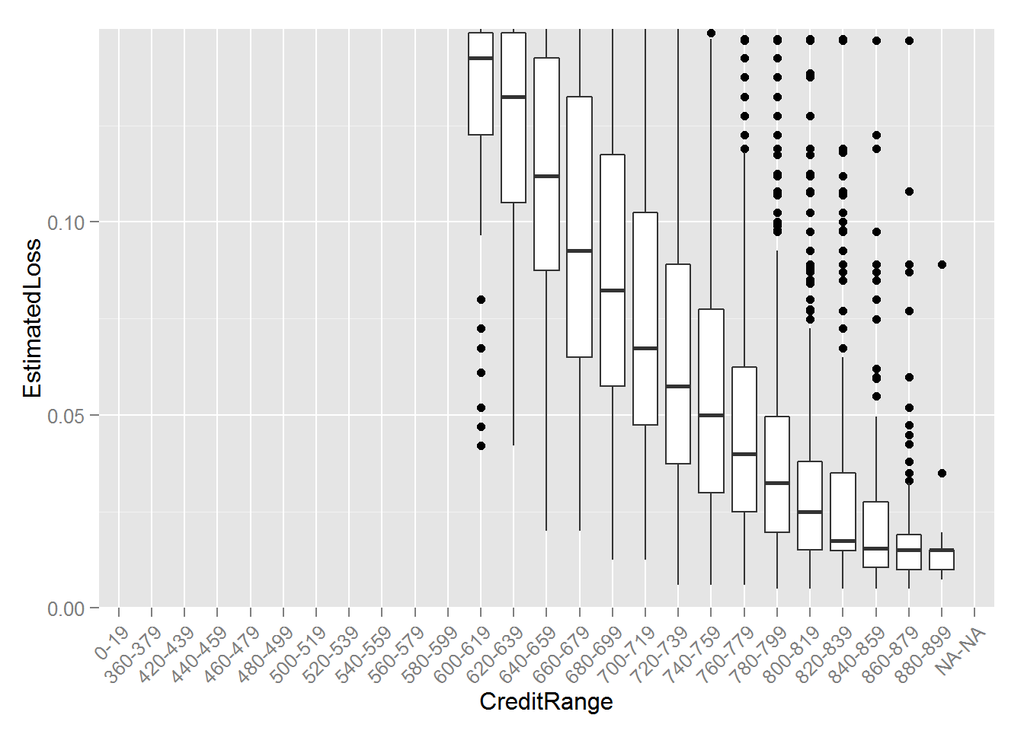

Higher credit score, lower estimated loss. Estimated loss’ means drops with the increase in credit range. The same phenomenon can be observed in the effect of Prosper Score on Estimated loss

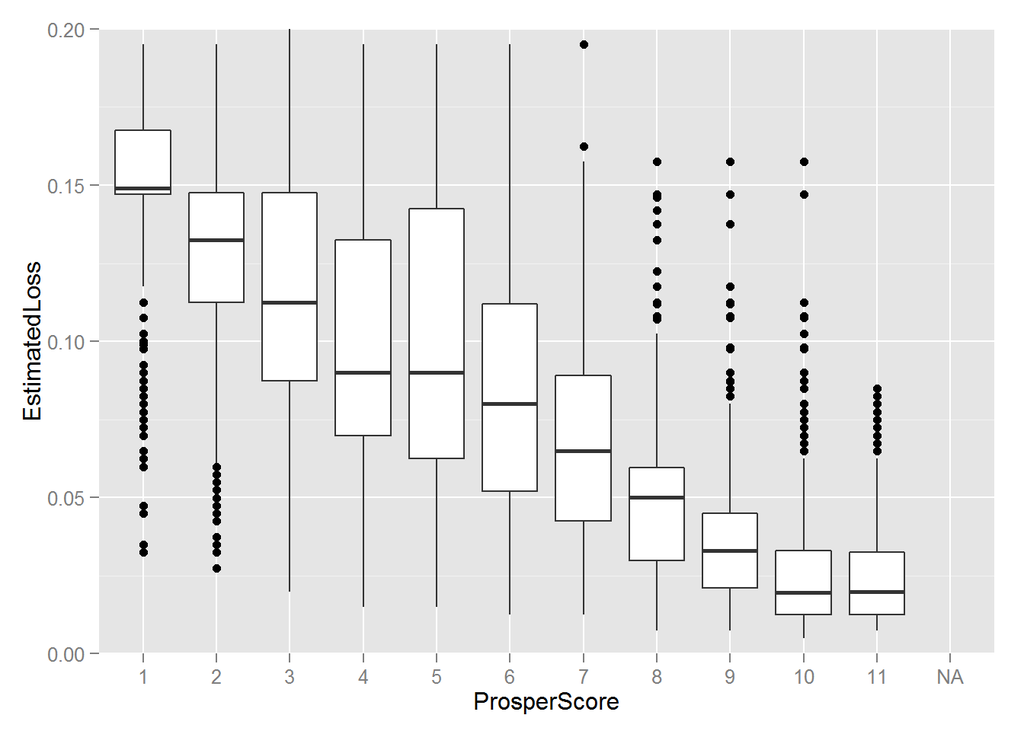

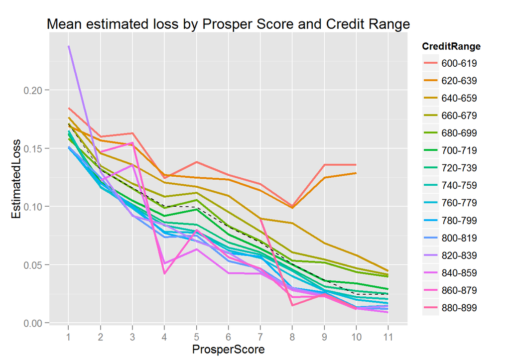

## Prosper Score

The Prosper score estimates the probability of a loan going “bad,” where “bad” is the probability of going 60+ days past due within the first twelve months from the date of loan origination. Applicants from April, 2008 through April, 2011 were used to build the discrete additive scorecard. The scorecard was verified and results validated on an independent validation sample of loans booked during the same time period as well as a more recent sample of loans booked outside of the loan development period.

Key variables in the scorecard are: - Number of inquiries on the credit bureau: InquiriesLast6Months - Number of delinquent accounts on the credit bureau: CurrentDelinquencies - Credit card utilization on the credit bureau: BankcardUtilization - Number of recently opened trades on the credit bureau: TradesOpenedLast6Months - Debt to income ratio: DebtToIncomeRatio - Loan payment performance on prior Prosper loans

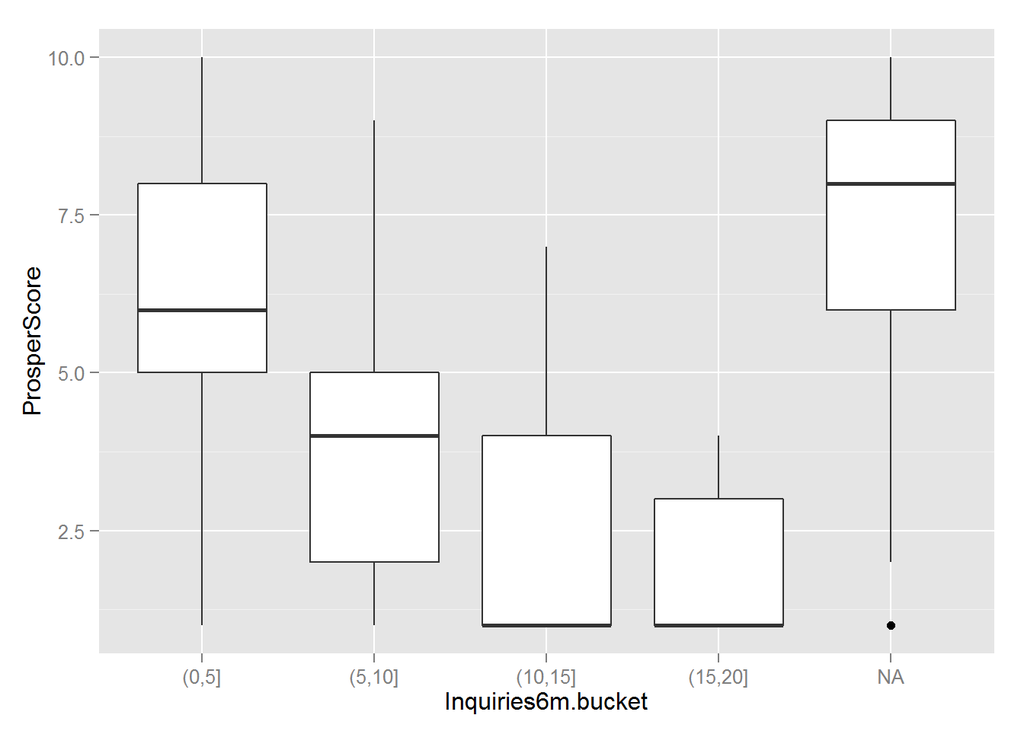

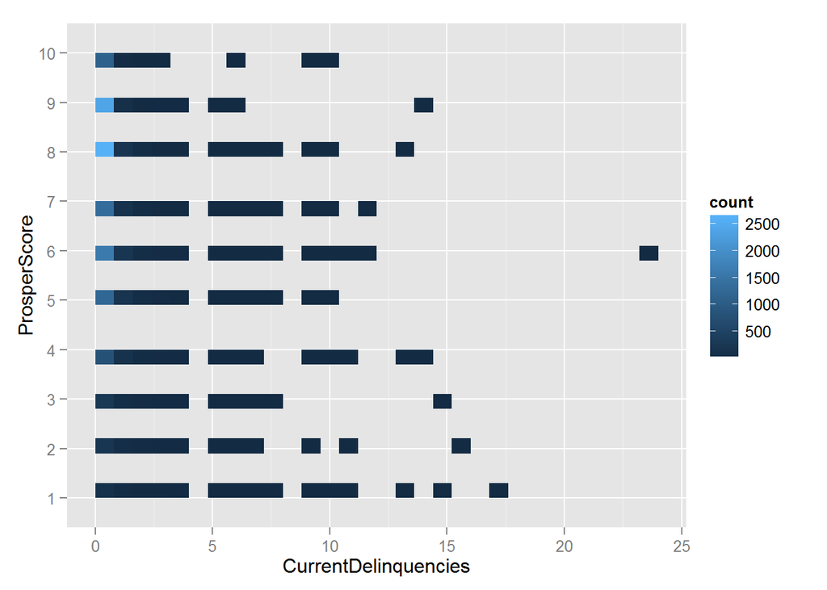

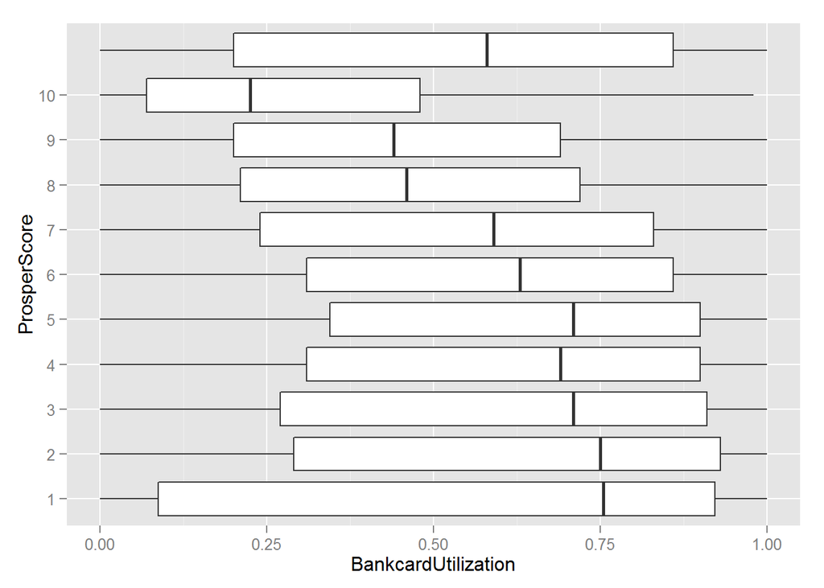

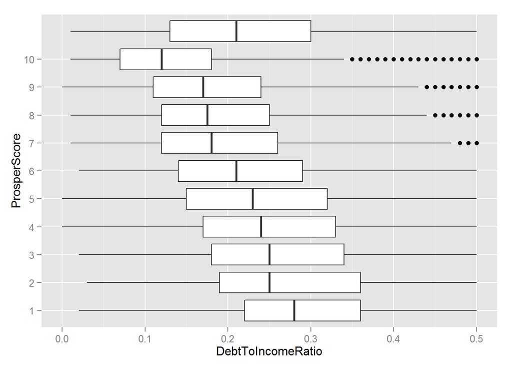

Trying to build a sub dataset from April 2008 to April 2011 and graphing the key variables in scorecard against the Prosper Score, I can see that Prosper Score has negative relationship with inquiries last 6 month, current delinquencies, bankcard utilization and debt to income ratio… However, this relationship is not clear and hard to quantify.

## II. What affect the loan interest rates

### Prosper rating and Credit Grade on Borrower Rate

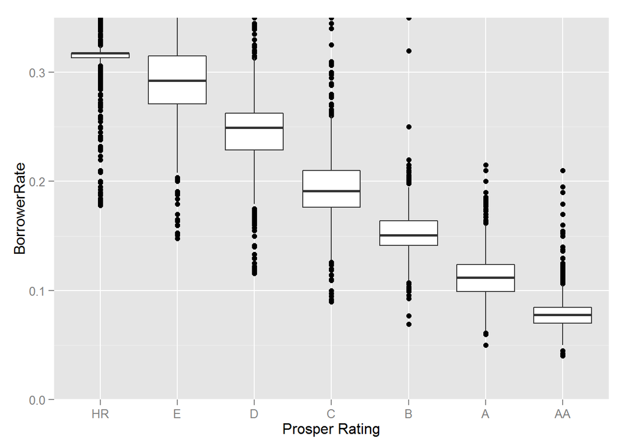

Clearly, Borrower Rate decreases when Prosper Rating increases. Before July 2009, Prosper used Credit Grade to calculate Borrower Rate. I’ll use graph Borrower Rate on Credit Grade for loan from 2005 to 2009

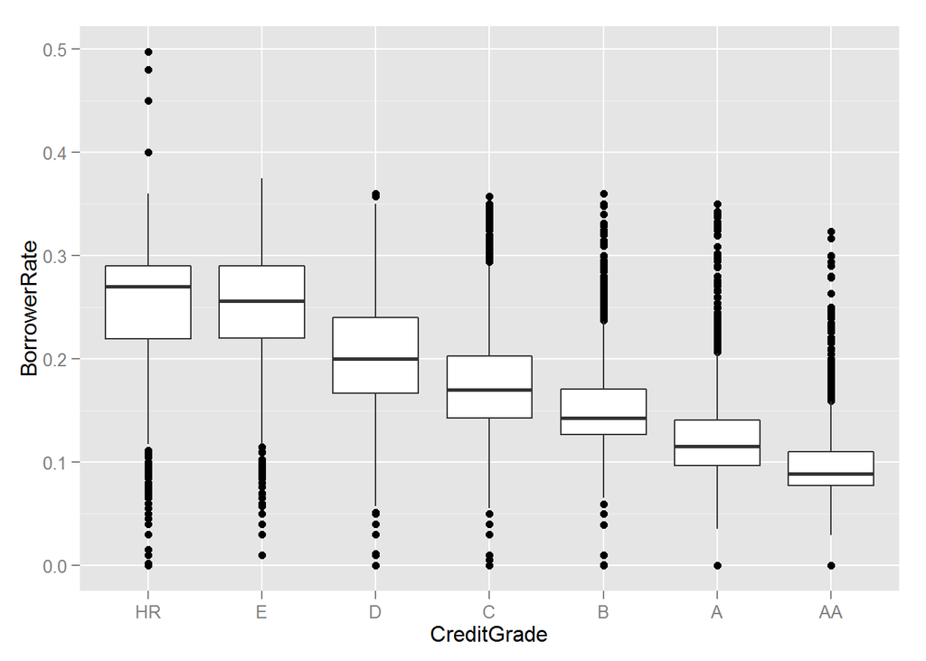

Although the same range of Borrower rate is assigned to the same level of credit grade and prosper rating, the fundamental difference is the way credit grade and prosper rating determined. Credit Grade is based only on credit bureau score (AA: 760+, HR: 520-559) Prosper Rating takes in various credit information of borrowers including prior prosper loans performance

### Estimated Loss on Borrower Rate

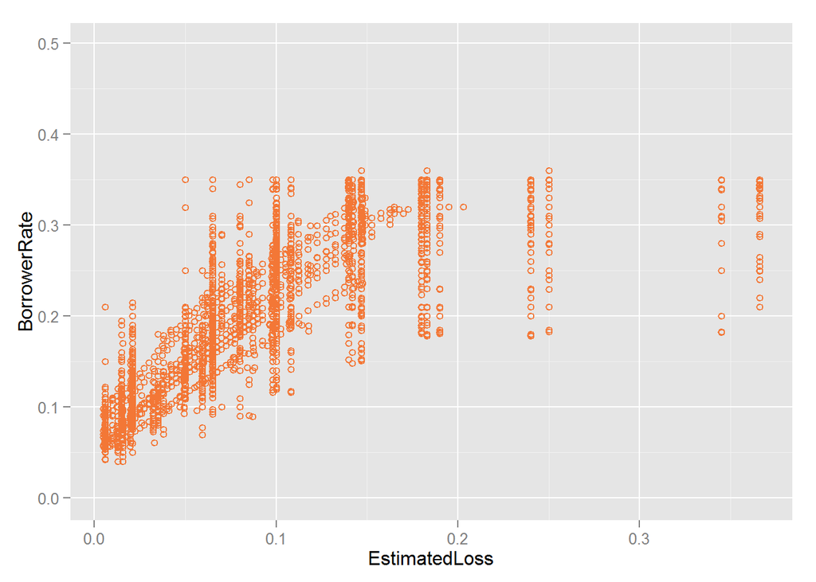

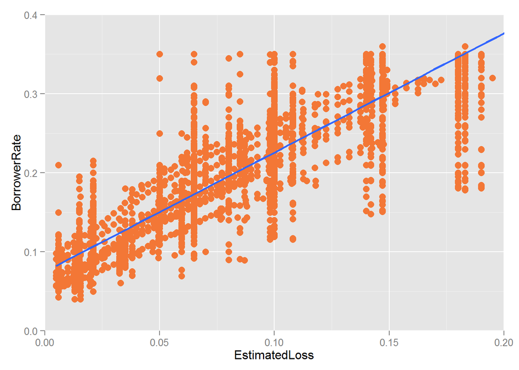

```
## [1] 0.945297
```

When estimated loss increases, borrower rate also increases and the borrower rate becomes more disperse. The correlation between estimated loss and borrower rate is high 94.5%, showing a strong and positive correlation

### Estimated Loss on Borrower Rate color by Prosper Rating

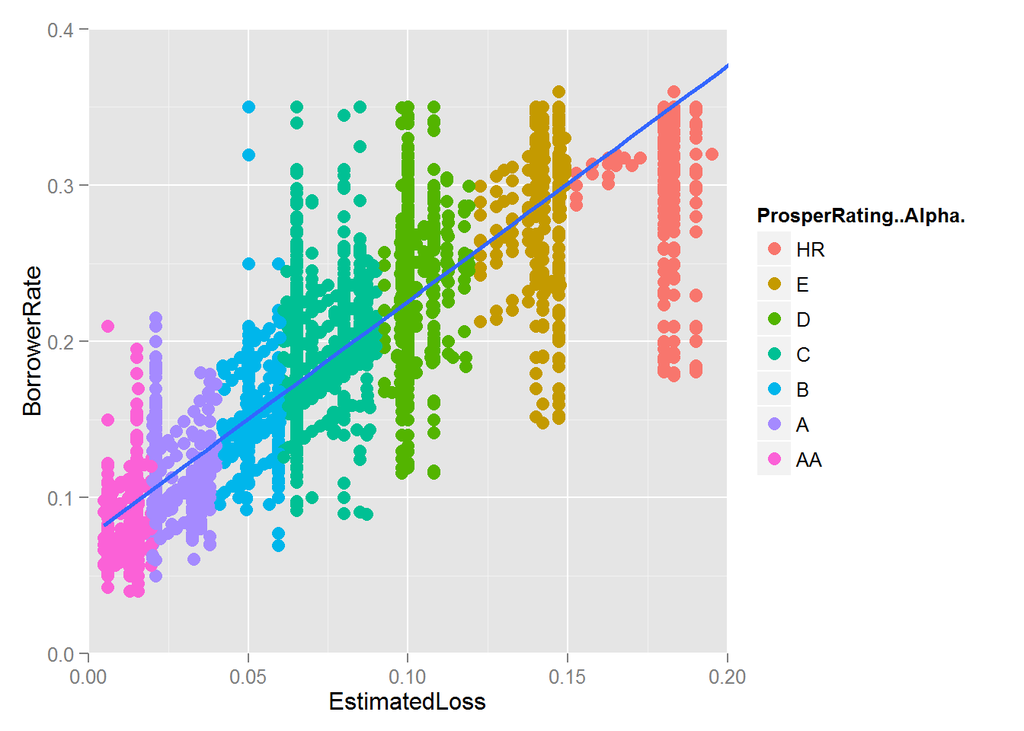

### Estimated Loss on Borrower Rate, facet by Term

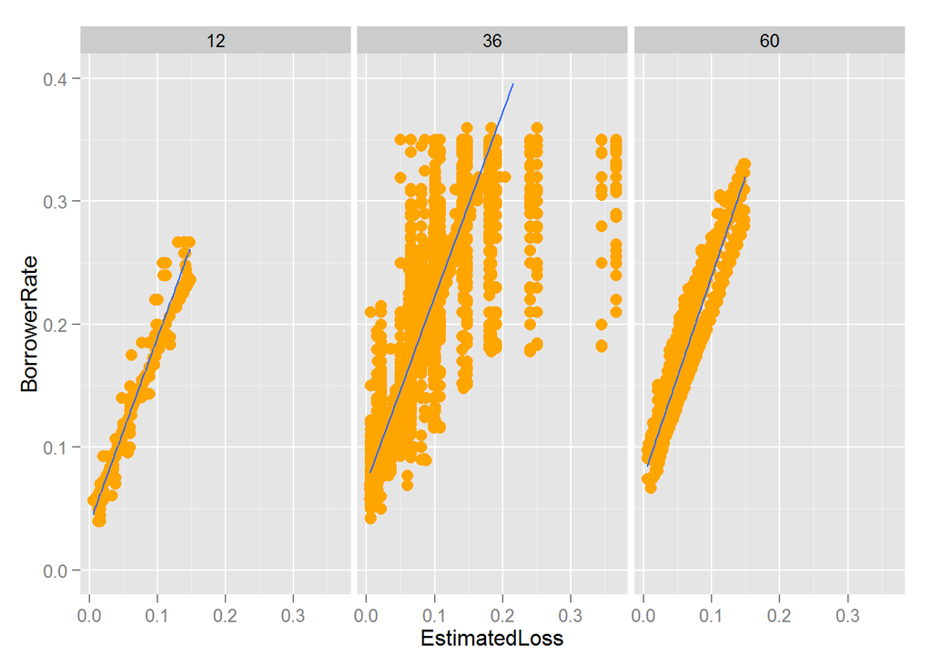

### What affect the difference between borrower rate and borrower APR

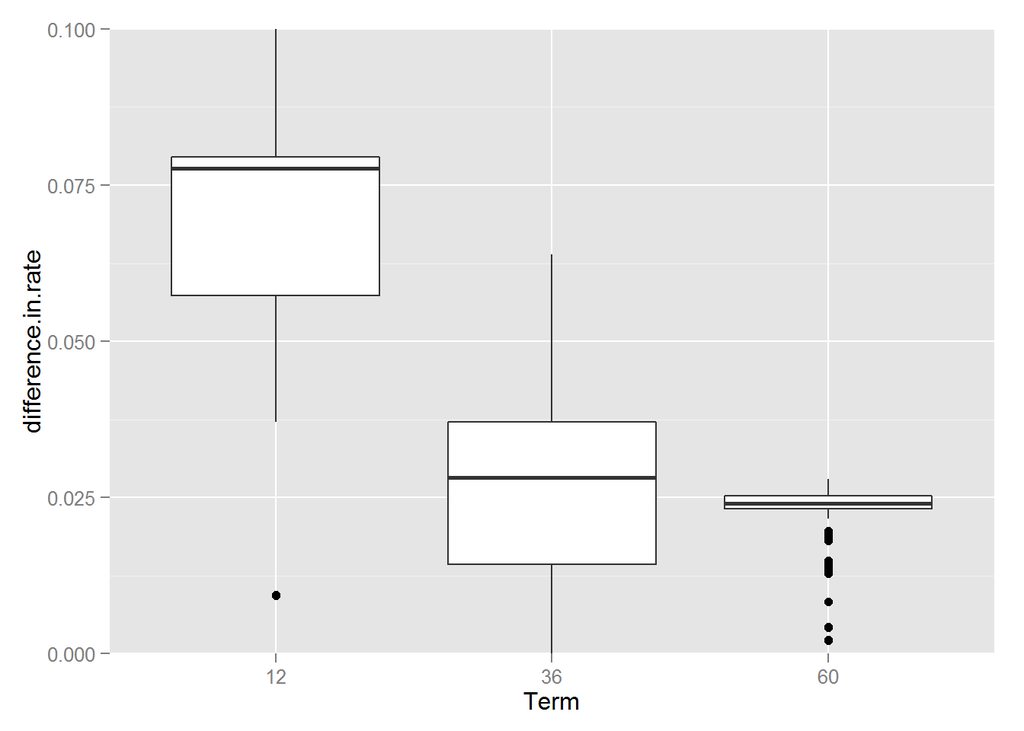

```
## dt$Term: 12
##    Min. 1st Qu.  Median    Mean 3rd Qu.    Max.
##   0.935   5.728   7.772   6.614   7.945  14.930
## --------------------------------------------------------
## dt$Term: 36
##    Min. 1st Qu.  Median    Mean 3rd Qu.    Max.    NA's
##   0.000   1.423   2.816   2.592   3.708   6.395      25
## --------------------------------------------------------
## dt$Term: 60
##    Min. 1st Qu.  Median    Mean 3rd Qu.    Max.
##   0.215   2.319   2.408   2.385   2.524   2.798
```

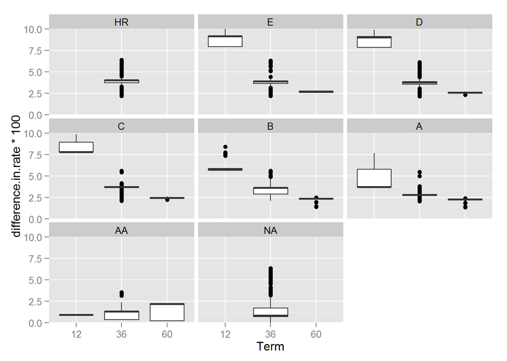

```
## dt$ProsperRating..Alpha.: HR
##    Min. 1st Qu.  Median    Mean 3rd Qu.    Max.
##   2.210   3.746   4.027   3.874   4.027   6.395
## --------------------------------------------------------
## dt$ProsperRating..Alpha.: E
##    Min. 1st Qu.  Median    Mean 3rd Qu.    Max.
##   2.174   3.631   3.891   3.721   3.948  10.080
## --------------------------------------------------------
## dt$ProsperRating..Alpha.: D
##    Min. 1st Qu.  Median    Mean 3rd Qu.    Max.
##   2.131   2.604   3.542   3.416   3.825   9.927
## --------------------------------------------------------
## dt$ProsperRating..Alpha.: C
##    Min. 1st Qu.  Median    Mean 3rd Qu.    Max.
##   2.095   2.440   3.393   3.169   3.722   9.835
## --------------------------------------------------------
## dt$ProsperRating..Alpha.: B
##    Min. 1st Qu.  Median    Mean 3rd Qu.    Max.
##   1.376   2.321   2.730   2.958   3.626   8.430
## --------------------------------------------------------
## dt$ProsperRating..Alpha.: A
##    Min. 1st Qu.  Median    Mean 3rd Qu.    Max.
##   1.340   2.252   2.788   2.597   2.819   7.674
## --------------------------------------------------------
## dt$ProsperRating..Alpha.: AA
##    Min. 1st Qu.  Median    Mean 3rd Qu.    Max.
##   0.215   0.343   1.336   1.092   1.346   3.562
```

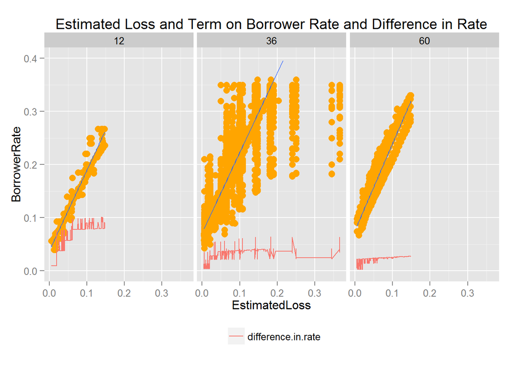

## Number of investors sponsoring a loan

**What draws investors to a loan**

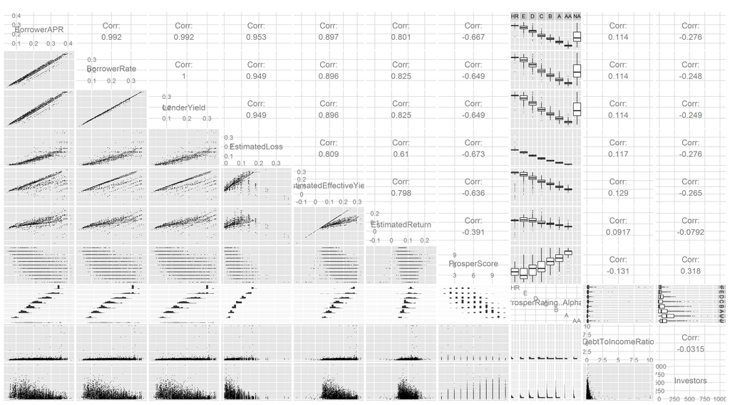

From this chart, I can see very good correlation among borrower rate, borrower APR, lender yield, effective yield and estimated return. This is obvious because these rates are calculated from each other. For example, lender’s yield is equal borrower rate less servicing fee. However, what astounds me the most is that these variables have very weak correlation with the investor count. For instance, correlation between lender’s yield and investors is only -0.249. This is beyond my expectation.

When continuous variables show little effect on investor number, I’ll try to graph the investor number against nominal variables such as prosper rating, income range, although relationship between nominal and continuous variables can be difficult to quantify.

**Prosper Rating on Investor counts**:

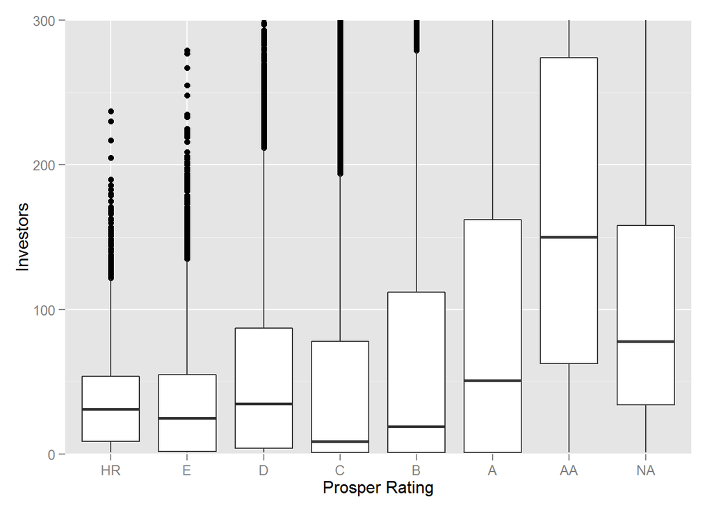

```
## dt$ProsperRating..Alpha.: HR
##    Min. 1st Qu.  Median    Mean 3rd Qu.    Max.
##    1.00    9.00   31.00   35.28   54.00  237.00
## --------------------------------------------------------
## dt$ProsperRating..Alpha.: E
##    Min. 1st Qu.  Median    Mean 3rd Qu.    Max.
##    1.00    2.00   25.00   35.01   55.00  279.00
## --------------------------------------------------------
## dt$ProsperRating..Alpha.: D
##    Min. 1st Qu.  Median    Mean 3rd Qu.    Max.
##    1.00    4.00   35.00   56.23   87.00  511.00
## --------------------------------------------------------
## dt$ProsperRating..Alpha.: C
##    Min. 1st Qu.  Median    Mean 3rd Qu.    Max.
##    1.00    1.00    9.00   51.09   78.00 1024.00
## --------------------------------------------------------
## dt$ProsperRating..Alpha.: B
##    Min. 1st Qu.  Median    Mean 3rd Qu.    Max.
##     1.0     1.0    19.0    69.8   112.0   856.0
## --------------------------------------------------------
## dt$ProsperRating..Alpha.: A
##    Min. 1st Qu.  Median    Mean 3rd Qu.    Max.
##    1.00    1.00   51.00   97.53  162.00 1189.00
## --------------------------------------------------------
## dt$ProsperRating..Alpha.: AA
##    Min. 1st Qu.  Median    Mean 3rd Qu.    Max.
##    1.00   62.75  150.00  178.40  274.00 1035.00
```

**Income Range on Investor counts**

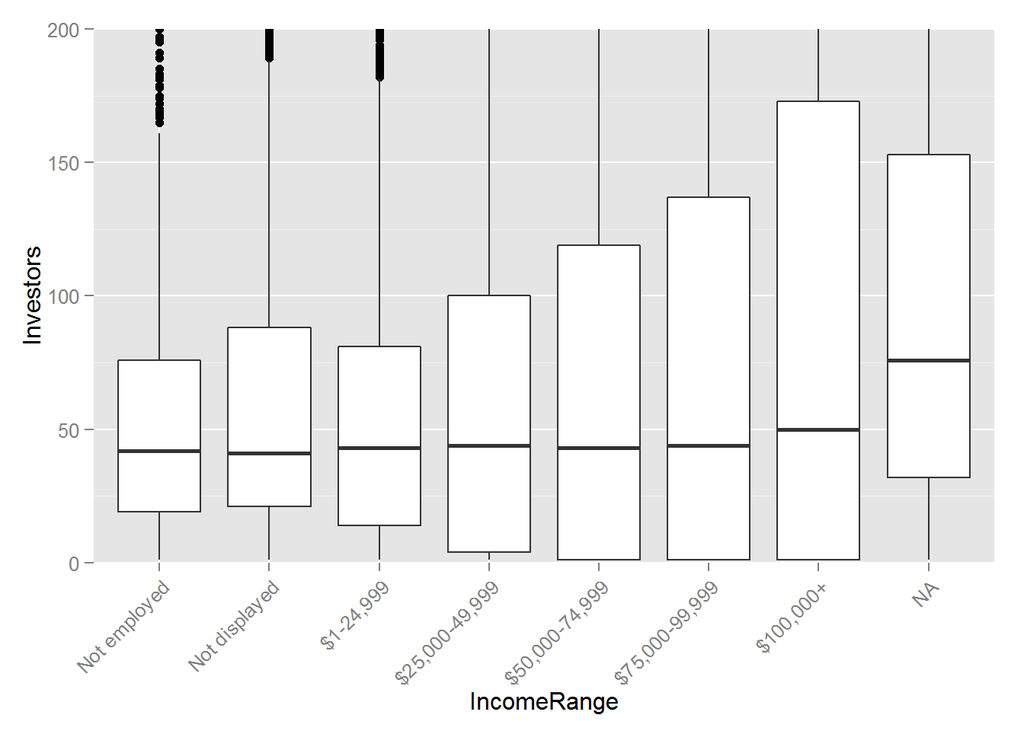

**Debt to Income Ratio on Investor count**

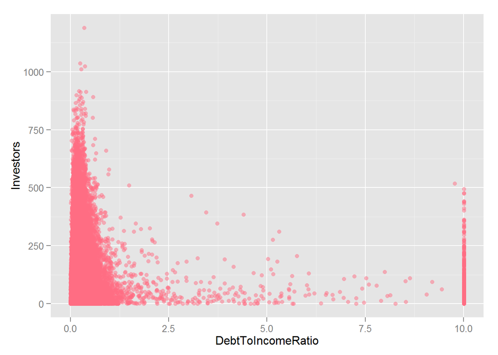

Borrowers who have debt to income ratio lower than 1 attract most investors (risk averse). However, there’re investors who accept very high debt to income ratio of 10.01 (which is larger than 1000 percent). Also this relationship is not linear, which explains why our correlation coefficient is very poor (0.00176)

**Lender Yield on Investor count**

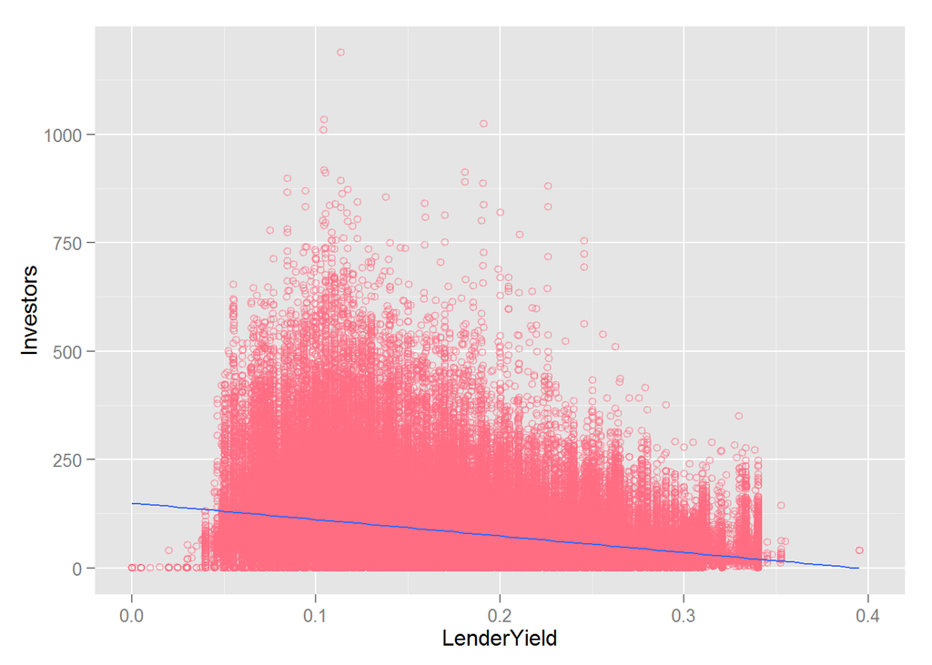

Investors don’t prefer very high lender yield because high lender yield means high borrower rate, means high risk. That’s why we can see the number of investors go down when lender yield increase. Most preferred rate is around 10%

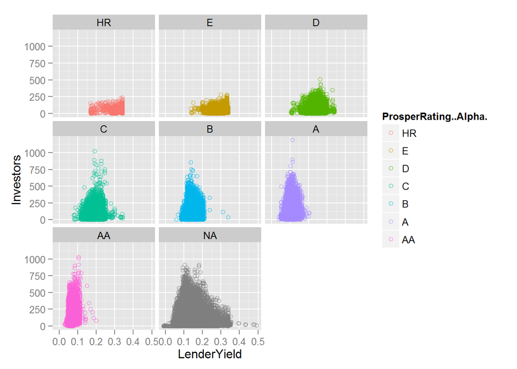

**Estimated return on Investor count**

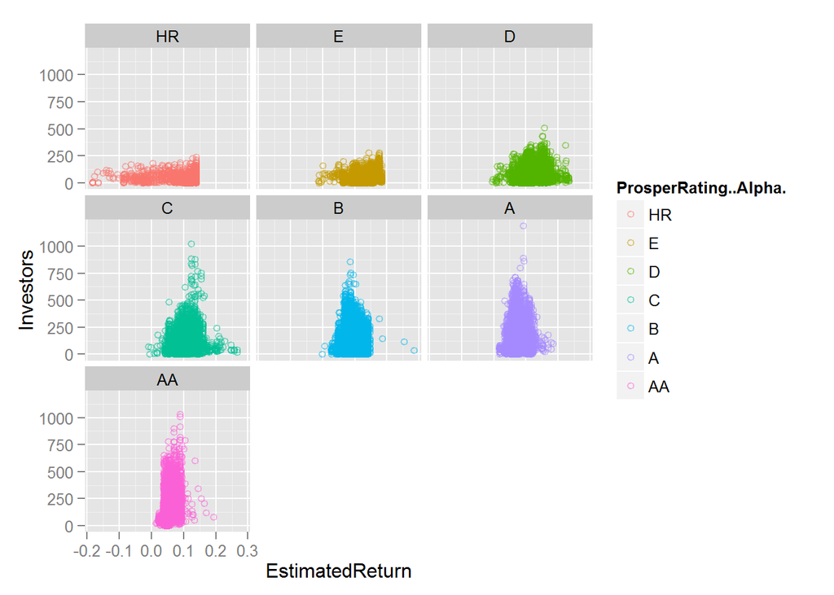

Similar to lender yield, investors prefer estimated return around 10%. When they invest in lower Prosper Rating loans, they expect higher return (10-20%). But there are also investors accept negative estimated returns and invest in HR loans.

**Loans with low and high number of investors:**

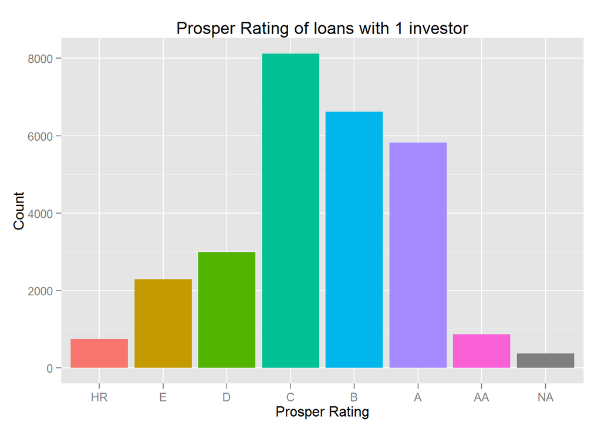

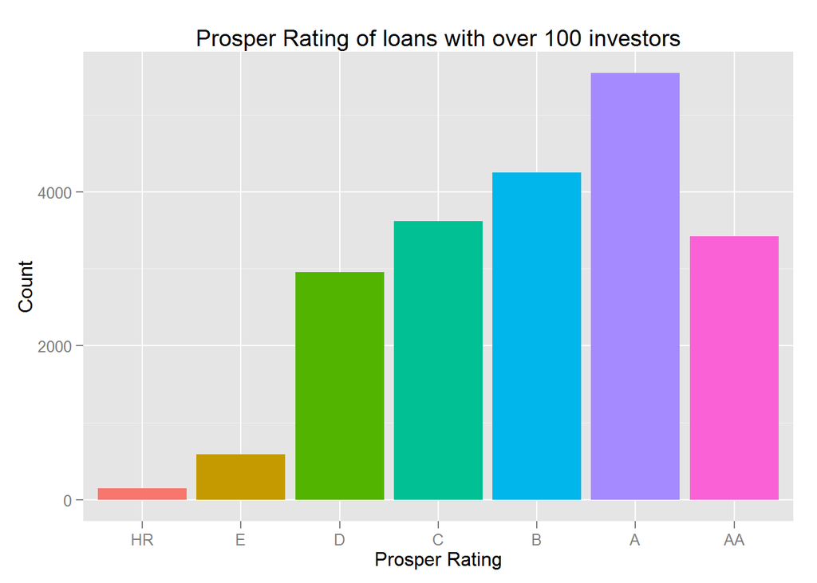

The popular rating for loans with only 1 investors is C with 8000 loans.The popular rating for loans with more than 100 investors are A with approximately 5500 counts.

## Underperformed loans

This section we will work with underperformed loans (charged-off loans) and discover their common patterns

```
## [1] 11992
```

```
## [1] 0.1052511
```

There are 11992 charged off loans (account for 10.5% )

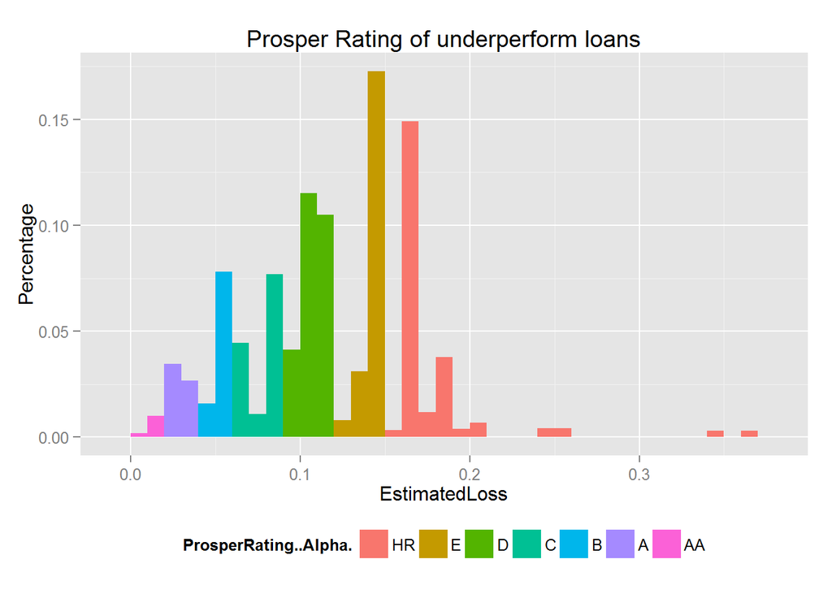

**Performance of charged off loan**

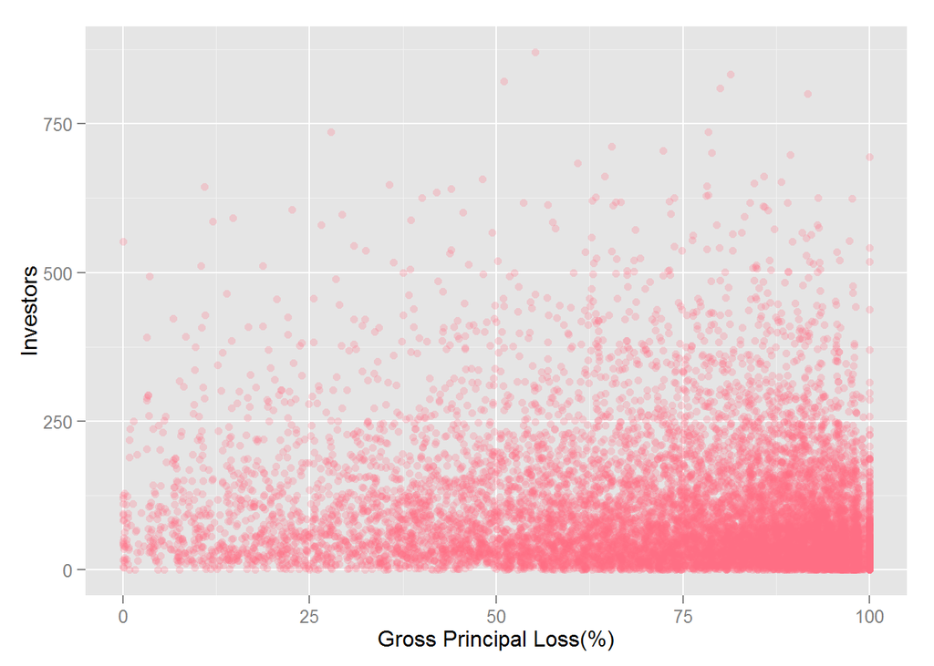

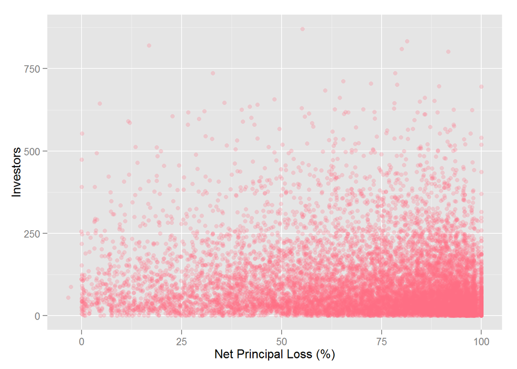

```
##
##     FALSE      TRUE
## 0.1882922 0.8117078
```

For both Gross Principal Loss and Net Principal Loss, the thickest area lies from 50% to 100% and under 100 investors. Nearly 81% of Net percentage loss is over 50%.

Facet the chart using Prosper Rating, we see how Prosper Rating affect the investors number to a loan (a pattern we have discovered earlier). Low investor count usually go with low Prosper rating, and those loans with low ratings tend to have high percentage loss when it comes to charge off loans

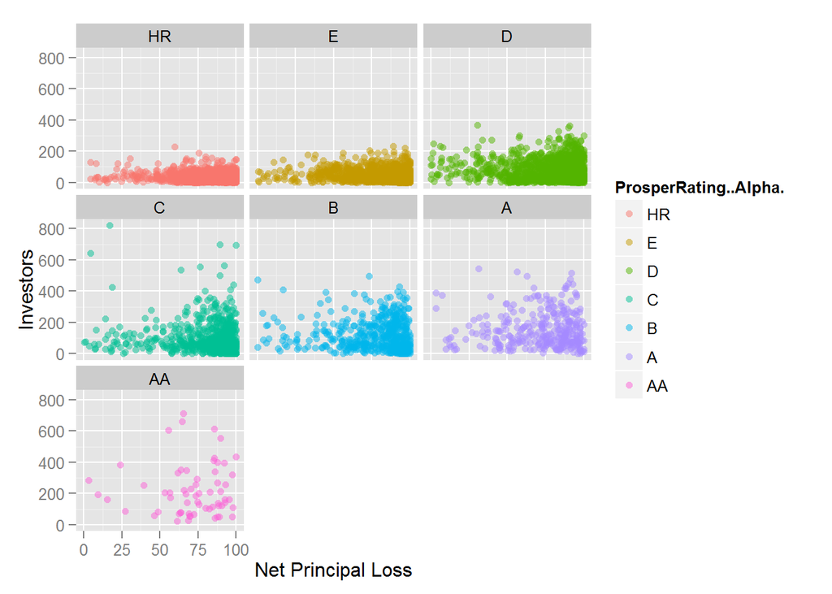

There are some cases, however, that the investors can recover of their investments. In those cases, Net Principal Loss is smaller than Gross Principal Loss. We can observe the phenomenon more clearly in the chart below where many points lie below the equate line of gross principal loss and net principal loss

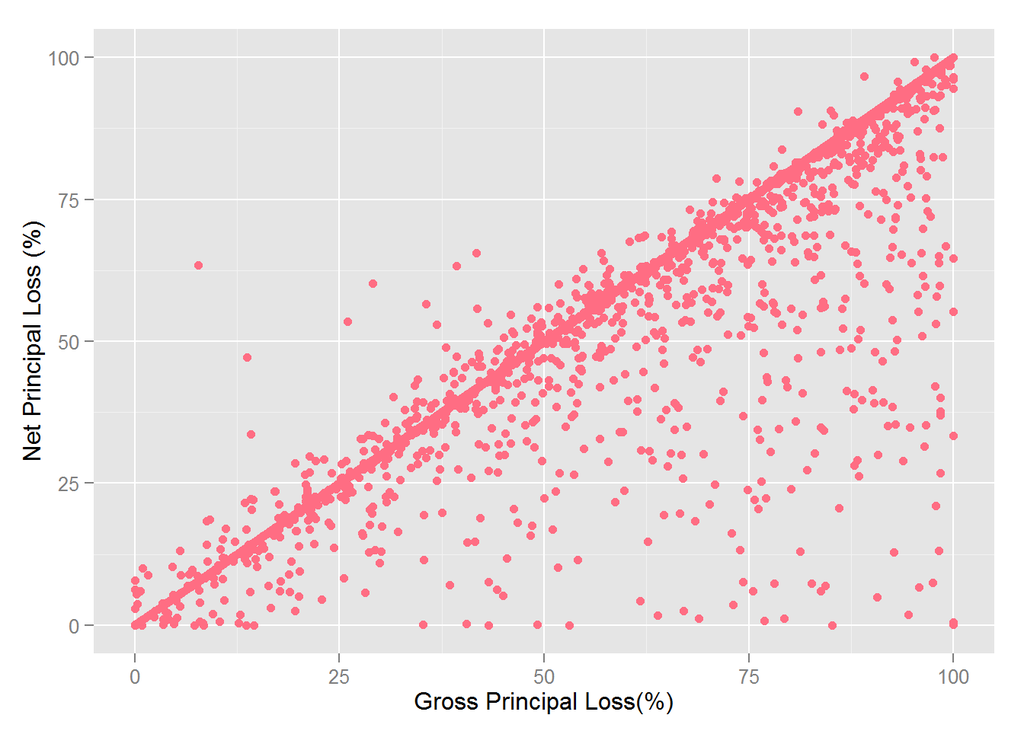

This brings me to a question of how accurate the estimated loss Prosper calculated in comparison to the actual loss investors have to suffer

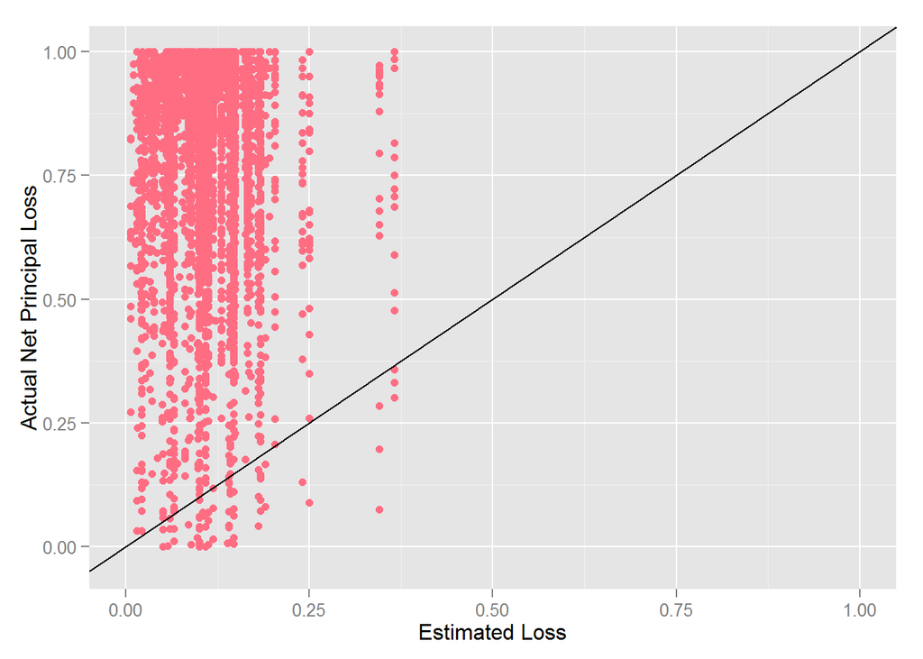

Sadly, the forecast is not even close. The actual loss is much higer than the estimated loss that Prosper uses to determine Prosper Rating based on such investors may make their decision.

# Bivariate and Multivariate Analysis

### Talk about some of the relationships you observed in this part of the investigation. How did the feature(s) of interest vary with other features in the dataset?

We learn from Loan purpose that most borrowers come to Prosper to find a means to settle their debt. This explains why Bank card utilization of most borrowers is high, and most of them don’t have very good prosper score, credit range as well as prosper rating.

Prosper uses Prosper Score and Credit Score to determine the Estimated Loss Rate. Estimated Loss Rate is then employed to calculate the Borrower Rate and to determine Prosper Rating. Term affects Borrower APR when Prosper imposes different service fee on different loan terms borrowers apply for.

Lender yield, Estimated effective yield and Estimated return are all derived from Borrower Rate. That’s why these rates show high correlation to each other. And because they are inter-dependent, it’s not useful to throw them together to predict effect on another variable (for example: investor count). At best, we can only use one of them as the predictor (lender yield or borrower rate, estimated loss rate). However, the correlation between such rate and investor count is negative and weak (~ -0.3%). This can infer that lenders participating to Prosper Loans are quite risk adverse. Still I cannot find any factors which affect investors’ decision strongly. Prosper Rating is a good indicator, but not a dominant factor. Hence, I think investor’s choice to invest in a loan is quite intuitive.

When investigating charged-off loans, I also realize that the estimated loss rate will not accurately predict the actual loss rate. Therefore, investors should be careful to base their decisions on such information.

### What was the strongest relationship you found?

The strongest relationship I’m able to observe in this dataset is between estimated loss rate and borrower rate. Hence, I will build linear model to predict borrower rate based on estimated loss rate

# Prediction Model

## Linear Model of Borrower Rate

Now I will build a model to predict the Borrower Rate based on Estimated Loss Rate as they show good correlation to each other. As Estimated Loss was only calculated after July 2009, I will predict based on a sub dataset after July 2009

```
##
## Calls:
## m1: lm(formula = BorrowerRate ~ EstimatedLoss, data = dtAfter2009)
##
## ===========================
## (Intercept)       0.075***
##                  (0.000)
## EstimatedLoss     1.509***
##                  (0.002)
## ---------------------------
## R-squared             0.894
## adj. R-squared        0.894
## sigma                 0.024
## F                712518.799
## p                     0.000
## Log-likelihood   194862.855
## Deviance             50.292
## AIC             -389719.710
## BIC             -389691.664
## N                 84853
## ===========================
```

So let assume a listing has Estimated Loss of 0.0049, what is the estimated value of borrower rate given confidence level of 95%

```
##          fit        lwr       upr
## 1 0.08226263 0.03454436 0.1299809
```

## Multilinear Model of Estimated Loss

```
##
## Calls:
## l1: lm(formula = EstimatedLoss ~ ProsperScore, data = dtAfter2009)
## l2: lm(formula = EstimatedLoss ~ ProsperScore + CreditRange, data = dtAfter2009)
##
## =====================================================
##                                   l1          l2
## -----------------------------------------------------
## (Intercept)                     0.159***    0.191***
##                                (0.000)     (0.001)
## ProsperScore                   -0.013***   -0.011***
##                                (0.000)     (0.000)
## CreditRange: 620-639/600-619               -0.007***
##                                            (0.001)
## CreditRange: 640-659/600-619               -0.020***
##                                            (0.001)
## CreditRange: 660-679/600-619               -0.033***
##                                            (0.001)
## CreditRange: 680-699/600-619               -0.041***
##                                            (0.001)
## CreditRange: 700-719/600-619               -0.049***
##                                            (0.001)
## CreditRange: 720-739/600-619               -0.054***
##                                            (0.001)
## CreditRange: 740-759/600-619               -0.057***
##                                            (0.001)
## CreditRange: 760-779/600-619               -0.060***
##                                            (0.001)
## CreditRange: 780-799/600-619               -0.065***
##                                            (0.001)
## CreditRange: 800-819/600-619               -0.067***
##                                            (0.001)
## CreditRange: 820-839/600-619               -0.066***
##                                            (0.001)
## CreditRange: 840-859/600-619               -0.068***
##                                            (0.002)
## CreditRange: 860-879/600-619               -0.067***
##                                            (0.003)
## CreditRange: 880-899/600-619               -0.065***
##                                            (0.008)
## -----------------------------------------------------
## R-squared                           0.454       0.545
## adj. R-squared                      0.454       0.545
## sigma                               0.035       0.032
## F                               70527.597    6764.427
## p                                   0.000       0.000
## Log-likelihood                 165141.180  172849.094
## Deviance                          101.331      84.497
## AIC                           -330276.360 -345664.187
## BIC                           -330248.314 -345505.260
## N                               84853       84853
## =====================================================
```

# Final Plots and Summary

### Plot One: Estimated Loss by Prosper Score and Credit Range

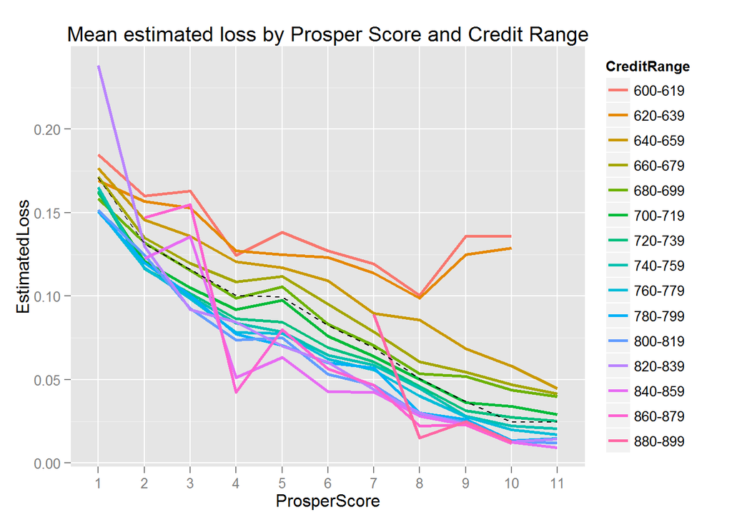

### Description One

This plot shows the effect of Prosper Score and Credit Range on Mean estimated loss. Estimated loss is higher with lower Prosper Score and Credit Range.

### Plot Two:

Borrower Rate and Borrower APR by Estimated Loss and Term

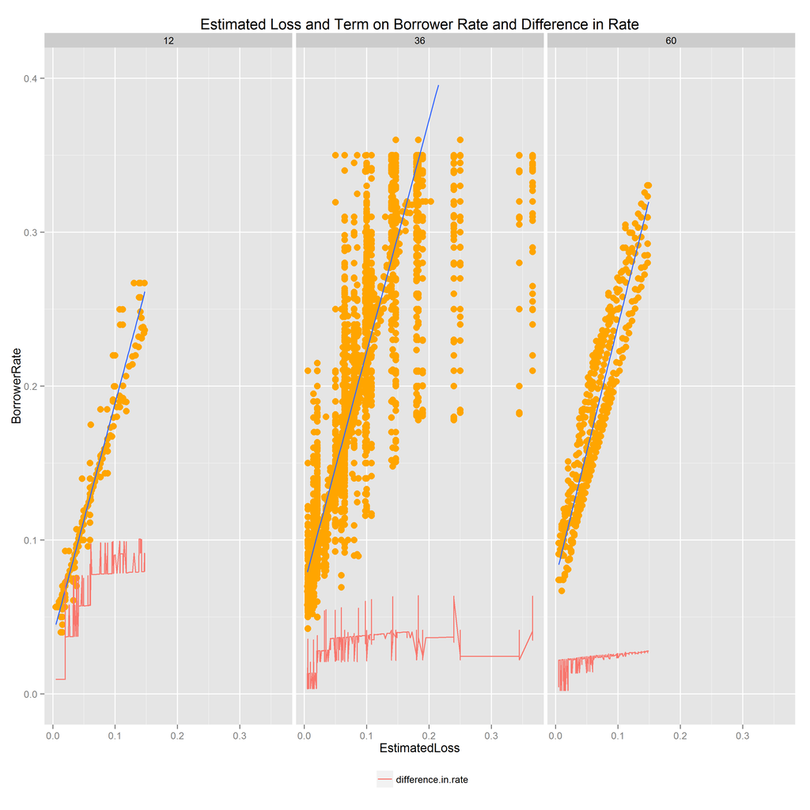

### Description Two

The second plot answers the question of what influence the Borrower Rate and Borrower APR. Since we can see the good linear relationship between Estimated Loss and Borrower Rate, as well as how Term affects the difference between Borrower Rate and APR, we have a better idea of what Prosper will look at when determining Borrower Rate and Borrower APR

### Plot Three:

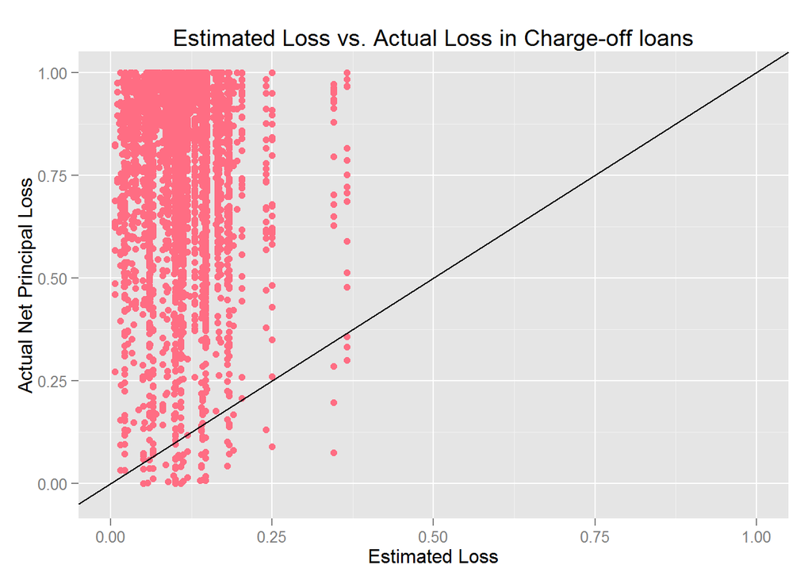

### Description Three

Watch out!!! Forecast is just forecast. The estimated loss rate is much lower than the actual loss rate when it comes to charge-off loans. As Prosper uses estimated loss rate to determine Prosper Rating, borrower rate and consequently lender’s yield as well as estimated return; lenders who merely base their decision on those factors are risking losing more than what they expect.

# Reflection

There are 81 variables in this dataset, but the variables used to make lending decisions are boiled down to several ones including Prosper Rating and Estimated Loss Rate; Prosper Score and Credit Range; Lender yield, estimated effective yield and estimated return… I wonder where borrowers’ information such as credit history, bankcard utilizaton, delinquencies,.. go into this process?

Prosper claims that they use a discrete scorecard built on applications from April 2008 to April 2011 to determine the Prosper Score. The scorecard takes in variables of borrowers’ credit information. However, graphing the Prosper Score against these variables, I see negative correlation but not enough to quantify. Lacking of domain knowledge, I was unable to build and test the effectiveness of this scorecard in determining Prosper Score, which in turn affects Estimated Loss Rate. Keeping in mind that Estimated Loss Rate is then used to decide Borrower Rate and Prosper Rating. The accuracy of the score card is critical to enhance Prosper’s ability to estimate yield and return for investors. However, from the dataset we can see that the accuracy of estimated loss rate is very poor. Investors should be careful when using these factors in their decision making process.